# Storm Surge Data

Samuel McDonnell

2024-03-13

```r
data <- readRDS("gtsr_daily_max_1979_2014.rds")
```

```r
head(data)
```

```
##   source station_name year month day surge_daily_max  date_time    lon    lat
## 1      1          748 1979     1   1           0.792 1979-01-01 -7.024 55.276
## 2      1          748 1979     1   2           0.589 1979-01-02 -7.024 55.276
## 3      1          748 1979     1   3           0.270 1979-01-03 -7.024 55.276
## 4      1          748 1979     1   4           0.414 1979-01-04 -7.024 55.276
## 5      1          748 1979     1   5           0.362 1979-01-05 -7.024 55.276
## 6      1          748 1979     1   6           0.507 1979-01-06 -7.024 55.276
```

```r
names(data)
```

```
## [1] "source"          "station_name"    "year"            "month"
## [5] "day"             "surge_daily_max" "date_time"       "lon"
## [9] "lat"
```

```r
levels(data$station_name)
```

```
##   [1] "748"   "749"   "782"   "783"   "784"   "785"   "786"   "787"   "788"
##  [10] "789"   "790"   "791"   "792"   "793"   "794"   "795"   "796"   "797"
##  [19] "798"   "799"   "800"   "801"   "802"   "803"   "804"   "805"   "806"
##  [28] "807"   "808"   "809"   "810"   "811"   "812"   "813"   "814"   "815"
##  [37] "816"   "817"   "818"   "819"   "820"   "821"   "822"   "823"   "824"
##  [46] "825"   "826"   "827"   "828"   "829"   "830"   "831"   "832"   "833"
##  [55] "834"   "835"   "836"   "837"   "838"   "839"   "840"   "841"   "842"
##  [64] "843"   "844"   "845"   "846"   "847"   "848"   "849"   "850"   "851"
##  [73] "852"   "853"   "854"   "855"   "856"   "857"   "858"   "859"   "860"
##  [82] "861"   "862"   "863"   "864"   "865"   "866"   "867"   "868"   "872"
##  [91] "873"   "874"   "875"   "876"   "877"   "878"   "879"   "880"   "881"
## [100] "882"   "883"   "884"   "885"   "886"   "887"   "888"   "889"   "890"
## [109] "891"   "892"   "893"   "894"   "895"   "896"   "897"   "898"   "899"
## [118] "900"   "901"   "902"   "903"   "904"   "905"   "906"   "907"   "908"
## [127] "909"   "910"   "911"   "912"   "913"   "914"   "916"   "917"   "918"
## [136] "919"   "920"   "921"   "923"   "924"   "925"   "926"   "927"   "928"
## [145] "929"   "930"   "931"   "932"   "933"   "934"   "935"   "936"   "937"
## [154] "938"   "939"   "940"   "941"   "942"   "943"   "944"   "945"   "946"
## [163] "947"   "948"   "949"   "950"   "951"   "952"   "953"   "954"   "955"
## [172] "956"   "957"   "958"   "959"   "960"   "961"   "962"   "963"   "964"
## [181] "965"   "966"   "967"   "968"   "969"   "970"   "971"   "972"   "973"
## [190] "20742" "20749" "20750" "20804" "20805" "20873" "20875" "20876" "20944"
## [199] "20945" "20946" "21078" "21079" "21141" "21143" "21194" "21196" "21245"
## [208] "21341" "21391" "21503" "21681" "38688" "38866" "39401" "39403" "39404"
## [217] "39411" "39413" "39421" "39422" "39429" "39435" "39445" "39470" "39471"
## [226] "39482" "39483" "41034" "41035" "41036" "41747"
```

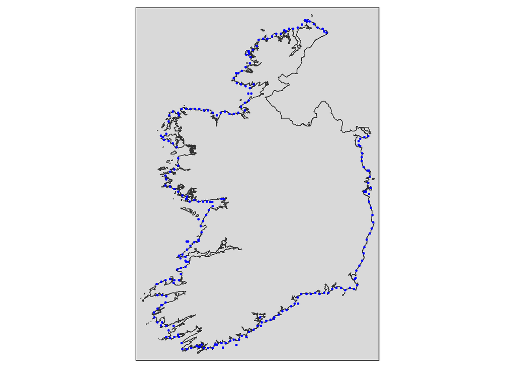

```r
set.seed(123)
#MAPPING THE LON AND LAT POINTS
library(sf)
library(ggplot2)
library(dplyr)
library(tmap)
library(tidyr)

#Load spatial data
ireland <- st_read("IRL_adm0.shp")
#UNIQUE COORDS FOR LAT AND LON
unique_coords <- unique(data[, c("lon", "lat")])

#CONVERT TO Sf object
unique_coords_sf <- st_as_sf(unique_coords, coords = c("lon", "lat"), crs = 4326)

#PLOT
tm_shape(ireland) +
  tm_borders() +
  tm_shape(unique_coords_sf) +
  tm_dots(col = "blue", size = 0.05, title = "Unique Coordinates") +
  tm_style("gray")
```

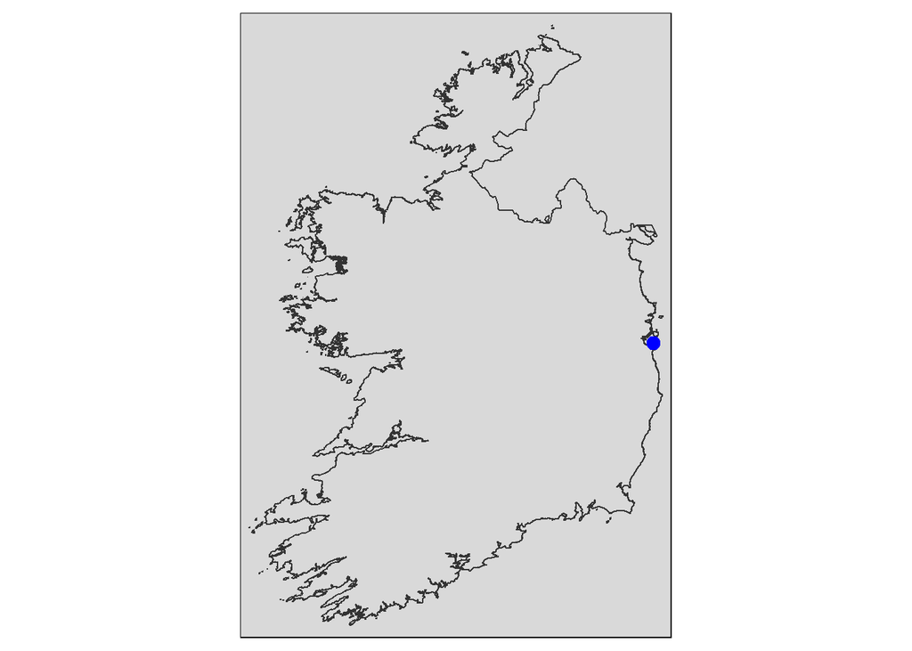

```r
dun_laoghaire<- subset(data, station_name == "795") #795 dun laoghaire

# Convert the selected point to an sf object
dun_laoghaire_sf <- st_as_sf(dun_laoghaire, coords = c("lon", "lat"), crs = 4326)

# Plot the map
tm_shape(ireland) +
  tm_borders() +
  tm_shape(dun_laoghaire_sf) +
  tm_dots(col = "blue", size = 0.5, title = "dun_laoghaire Observation") +
  tm_style("gray")
```

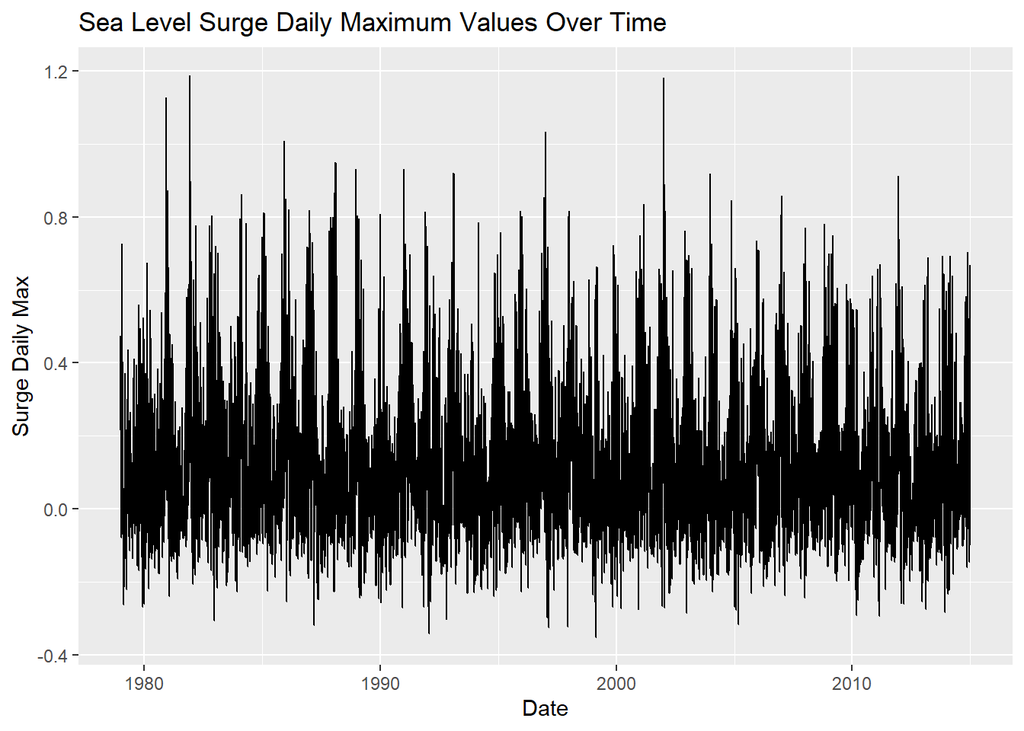

```r
# Time series plot
ggplot(dun_laoghaire, aes(x = as.Date(date_time), y = surge_daily_max)) +
  geom_line() +
  labs(title = "Sea Level Surge Daily Maximum Values Over Time",
       x = "Date", y = "Surge Daily Max")
```

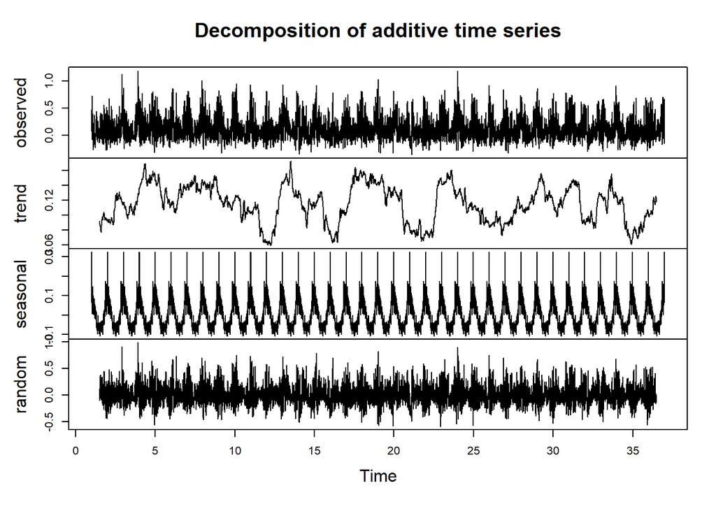

```r
# Seasonal decomposition additive
ts_data <- ts(dun_laoghaire$surge_daily_max, frequency = 365.25)
ts_decomp <- decompose(ts_data)
plot(ts_decomp)
```

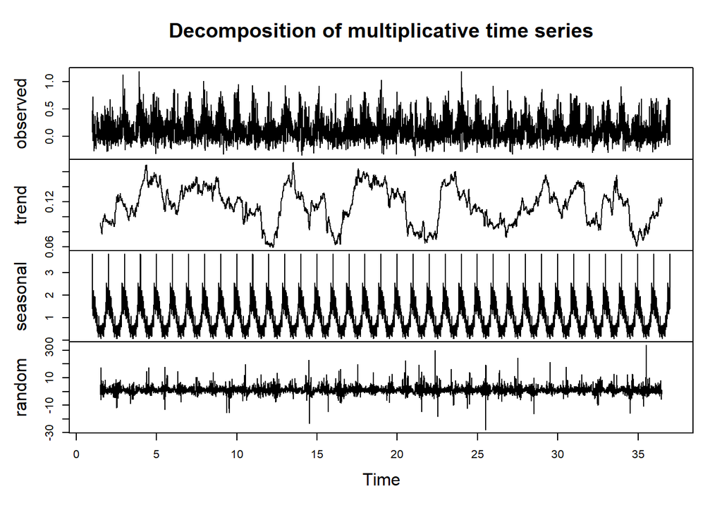

```r
#multiplicative
ts_data2 <- ts(dun_laoghaire$surge_daily_max, frequency = 365.25)
ts_decomp2 <- decompose(ts_data2, type = "multiplicative")
plot(ts_decomp2)
```

```r
# Define custom ordering of months from July to June
custom_order <- c("Jul", "Aug", "Sep", "Oct", "Nov", "Dec", "Jan", "Feb", "Mar", "Apr", "May", "Jun")

# Convert month integer to corresponding month abbreviation
dun_laoghaire$month <- factor(month.abb[dun_laoghaire$month], levels = custom_order)

# Calculate monthly averages
monthly_avg <- dun_laoghaire %>%
  group_by(year, month) %>%
  summarize(avg_surge_daily_max = mean(surge_daily_max), na.rm = TRUE) %>%
  ungroup() %>%
  mutate(time_index = 1:n())
```

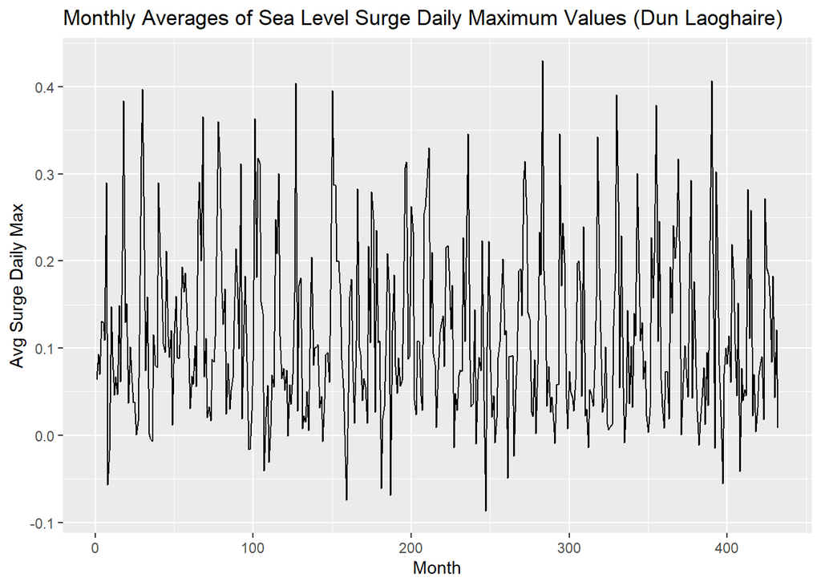

```r
annual_avg <- dun_laoghaire %>%
  group_by(year) %>%
  summarize(avg_surge_daily_max = mean(surge_daily_max), na.rm = TRUE) %>%
  ungroup() %>%
  mutate(time_index = 1:n())


# Plot monthly averages with custom ordering
ggplot(monthly_avg, aes(x = time_index, y = avg_surge_daily_max, group = 1)) +
  geom_line() +
  labs(title = "Monthly Averages of Sea Level Surge Daily Maximum Values (Dun Laoghaire)",
       x = "Month", y = "Avg Surge Daily Max")
```

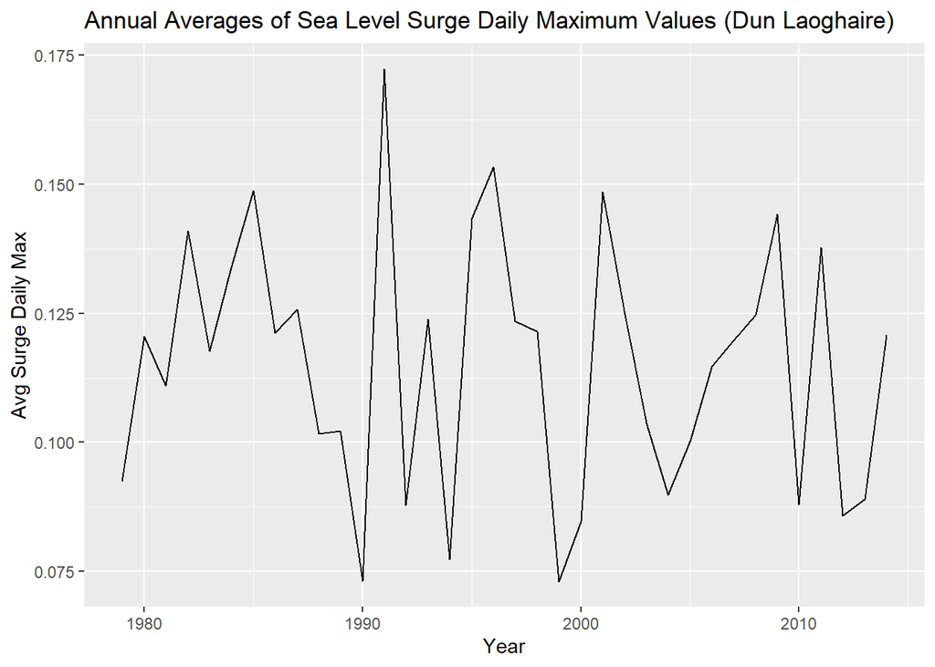

```r
ggplot(annual_avg, aes(x = year, y = avg_surge_daily_max, group = 1)) +
  geom_line() +
  labs(title = "Annual Averages of Sea Level Surge Daily Maximum Values (Dun Laoghaire)",
       x = "Year", y = "Avg Surge Daily Max")
```

Two approaches to analyzing the extremes of a dataset. First: Divide the data into blocks and take the maximum of each block. (GEV df) Second: Take values over a certain high threshold. (Pareto or GP df)

Which approach will we take?

For one location, find the extreme values using both threshold and block maxima methods.(GEV/GP methods) Estimate the parameters of the distribution using statistical techniques such as maximum likelihood estimation (MLE) or method of moments. With the fitted model parameters, can make inferences about extreme events, such as estimating return levels (e.g., 50-year return level) or quantiles corresponding to certain probabilities of exceedance. can also use the model to predict future extreme events based on historical data.

Heatmap Generation: create a heatmap visualization of extreme values. Each coastal location can be represented by a point on the map, with the intensity of color indicating the magnitude or frequency of extreme events at that location. You can also overlay administrative boundaries or other relevant geographic features to provide context. By creating a heatmap of extreme values across multiple coastal locations in Ireland, you can identify hotspots of extreme events

Interactive Visualization: Consider creating an interactive heatmap that allows users to explore extreme values at different locations by zooming, panning, or hovering over data points.(might be cool but not useful for a thesis?)

```r
library(extRemes)
# Threshold method (GEV/GP)
# Define threshold value
threshold <- quantile(dun_laoghaire$surge_daily_max, probs = 0.9) #.9 has lower neg log likelihood than 0.95
dun_laoghaire_above_threshold <- dun_laoghaire %>% filter(surge_daily_max > threshold) ### the input should be the data that is above the threshold

dun_laoghaire_annual_max <- dun_laoghaire %>% group_by(year) %>% summarise(annual_max = max(surge_daily_max))

# Fit GEV distribution to threshold exceedances
gev_fit <- fevd(dun_laoghaire_above_threshold$surge_daily_max, threshold = threshold, method = "MLE")

# Fit GEV distribution to block maxima
gev_block_fit <- fevd(dun_laoghaire_annual_max$annual_max, method = "MLE")

# Display results
print("Threshold Method (GEV/GP):")
```

```
## [1] "Threshold Method (GEV/GP):"
```

```r
print(summary(gev_fit))
```

```
##
## fevd(x = dun_laoghaire_above_threshold$surge_daily_max, threshold = threshold,
##     method = "MLE")
##
## [1] "Estimation Method used: MLE"
##
##
##  Negative Log-Likelihood Value:  -1160.268
##
##
##  Estimated parameters:
##   location      scale      shape
## 0.43850380 0.06866226 0.39201765
##
##  Standard Error Estimates:
##    location       scale       shape
## 0.002406148 0.002151238 0.038128389
##
##  Estimated parameter covariance matrix.
##               location         scale         shape
## location  5.789550e-06  3.877817e-06 -4.419857e-05
## scale     3.877817e-06  4.627823e-06 -2.246575e-05
## shape    -4.419857e-05 -2.246575e-05  1.453774e-03
##
##  AIC = -2314.535
##
##  BIC = -2298.993
## $par
##   location      scale      shape
## 0.43850380 0.06866226 0.39201765
##
## $cov.theta
##               location         scale         shape
## location  5.789550e-06  3.877817e-06 -4.419857e-05
## scale     3.877817e-06  4.627823e-06 -2.246575e-05
## shape    -4.419857e-05 -2.246575e-05  1.453774e-03
##
## $se.theta
##    location       scale       shape
## 0.002406148 0.002151238 0.038128389
##
## $nllh
## [1] -1160.268
##
## $AIC
## [1] -2314.535
##
## $BIC
## [1] -2298.993
```

```r
cat("\n")
```

```r
print("Block Maxima Method (GEV/GP):")
```

```
## [1] "Block Maxima Method (GEV/GP):"
```

```r
print(summary(gev_block_fit))
```

```
##
## fevd(x = dun_laoghaire_annual_max$annual_max, method = "MLE")
##
## [1] "Estimation Method used: MLE"
##
##
##  Negative Log-Likelihood Value:  -20.97111
##
##
##  Estimated parameters:
##    location       scale       shape
##  0.76590376  0.11673601 -0.02743456
##
##  Standard Error Estimates:
##   location      scale      shape
## 0.02220820 0.01616338 0.13539830
##
##  Estimated parameter covariance matrix.
##               location         scale         shape
## location  0.0004932044  0.0001349300 -0.0011832165
## scale     0.0001349300  0.0002612550 -0.0008134184
## shape    -0.0011832165 -0.0008134184  0.0183327004
##
##  AIC = -35.94222
##
##  BIC = -31.19166
## $par
##    location       scale       shape
##  0.76590376  0.11673601 -0.02743456
##
## $cov.theta
##               location         scale         shape
## location  0.0004932044  0.0001349300 -0.0011832165
## scale     0.0001349300  0.0002612550 -0.0008134184
## shape    -0.0011832165 -0.0008134184  0.0183327004
##
## $se.theta
##   location      scale      shape
## 0.02220820 0.01616338 0.13539830
##
## $nllh
## [1] -20.97111
##
## $AIC
## [1] -35.94222
##
## $BIC
## [1] -31.19166
```

```r
#AIC and BIC, neg log likelihood all much better for threshold method
```

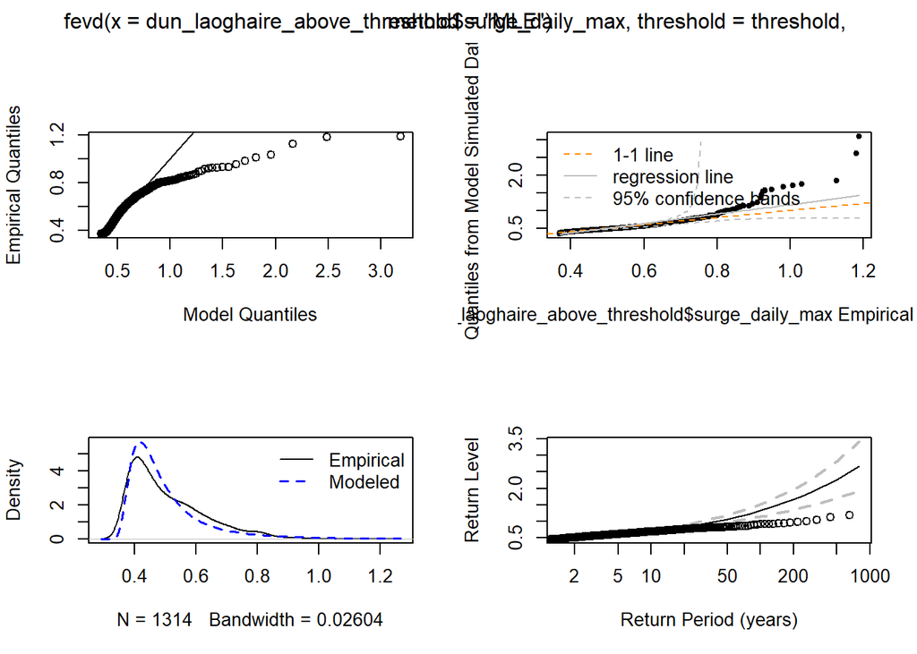

```r
#what does the gev distribution look like once you've estimated parameters
plot(gev_fit) #threshold
```

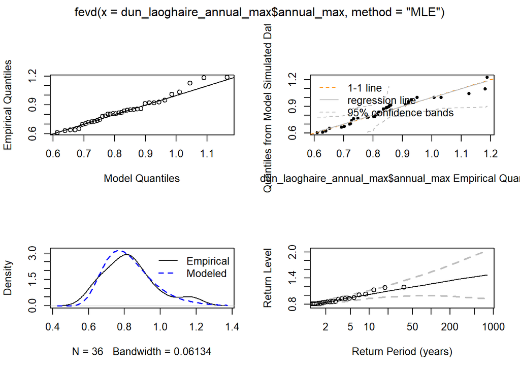

```r
plot(gev_block_fit) ## plot block max fit (looks better, fits inside confidence intervals)
```